# Wine Exploration by Mack Damavandi

This report explores a dataset that contains data on approximately 5,000 different white wines. Although I don’t drink alcohol, I sometimes use it in cooking. I chose this dataset because white wine is the type of alcohol that I have the most familiarity with.

# Univariate Plots Section

```
## [1] 4898   13
```

```
## 'data.frame':    4898 obs. of  13 variables:
##  $ X                   : int  1 2 3 4 5 6 7 8 9 10 ...
##  $ fixed.acidity       : num  7 6.3 8.1 7.2 7.2 8.1 6.2 7 6.3 8.1 ...
##  $ volatile.acidity    : num  0.27 0.3 0.28 0.23 0.23 0.28 0.32 0.27 0.3 0.22 ...
##  $ citric.acid         : num  0.36 0.34 0.4 0.32 0.32 0.4 0.16 0.36 0.34 0.43 ...
##  $ residual.sugar      : num  20.7 1.6 6.9 8.5 8.5 6.9 7 20.7 1.6 1.5 ...
##  $ chlorides           : num  0.045 0.049 0.05 0.058 0.058 0.05 0.045 0.045 0.049 0.044 ...
##  $ free.sulfur.dioxide : num  45 14 30 47 47 30 30 45 14 28 ...
##  $ total.sulfur.dioxide: num  170 132 97 186 186 97 136 170 132 129 ...
##  $ density             : num  1.001 0.994 0.995 0.996 0.996 ...
##  $ pH                  : num  3 3.3 3.26 3.19 3.19 3.26 3.18 3 3.3 3.22 ...
##  $ sulphates           : num  0.45 0.49 0.44 0.4 0.4 0.44 0.47 0.45 0.49 0.45 ...
##  $ alcohol             : num  8.8 9.5 10.1 9.9 9.9 10.1 9.6 8.8 9.5 11 ...
##  $ quality             : int  6 6 6 6 6 6 6 6 6 6 ...
```

```
##  fixed.acidity    volatile.acidity  citric.acid     residual.sugar
##  Min.   : 3.800   Min.   :0.0800   Min.   :0.0000   Min.   : 0.600
##  1st Qu.: 6.300   1st Qu.:0.2100   1st Qu.:0.2700   1st Qu.: 1.700
##  Median : 6.800   Median :0.2600   Median :0.3200   Median : 5.200
##  Mean   : 6.855   Mean   :0.2782   Mean   :0.3342   Mean   : 6.391
##  3rd Qu.: 7.300   3rd Qu.:0.3200   3rd Qu.:0.3900   3rd Qu.: 9.900
##  Max.   :14.200   Max.   :1.1000   Max.   :1.6600   Max.   :65.800
##    chlorides       free.sulfur.dioxide total.sulfur.dioxide
##  Min.   :0.00900   Min.   :  2.00      Min.   :  9.0
##  1st Qu.:0.03600   1st Qu.: 23.00      1st Qu.:108.0
##  Median :0.04300   Median : 34.00      Median :134.0
##  Mean   :0.04577   Mean   : 35.31      Mean   :138.4
##  3rd Qu.:0.05000   3rd Qu.: 46.00      3rd Qu.:167.0
##  Max.   :0.34600   Max.   :289.00      Max.   :440.0
##     density             pH          sulphates         alcohol
##  Min.   :0.9871   Min.   :2.720   Min.   :0.2200   Min.   : 8.00
##  1st Qu.:0.9917   1st Qu.:3.090   1st Qu.:0.4100   1st Qu.: 9.50
##  Median :0.9937   Median :3.180   Median :0.4700   Median :10.40
##  Mean   :0.9940   Mean   :3.188   Mean   :0.4898   Mean   :10.51
##  3rd Qu.:0.9961   3rd Qu.:3.280   3rd Qu.:0.5500   3rd Qu.:11.40
##  Max.   :1.0390   Max.   :3.820   Max.   :1.0800   Max.   :14.20
##     quality
##  Min.   :3.000
##  1st Qu.:5.000
##  Median :6.000
##  Mean   :5.878
##  3rd Qu.:6.000
##  Max.   :9.000
```

This dataset contains 11 attributes that describe white wine and one attribute that is a rating of the quality of the white wine by a wine expert.

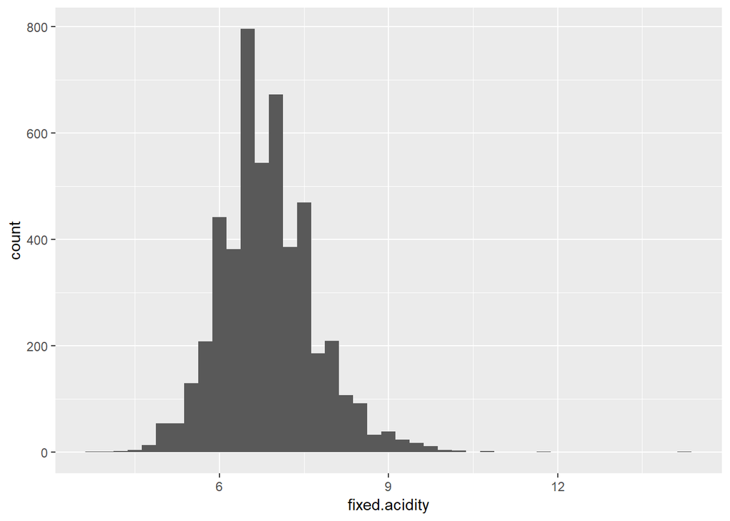

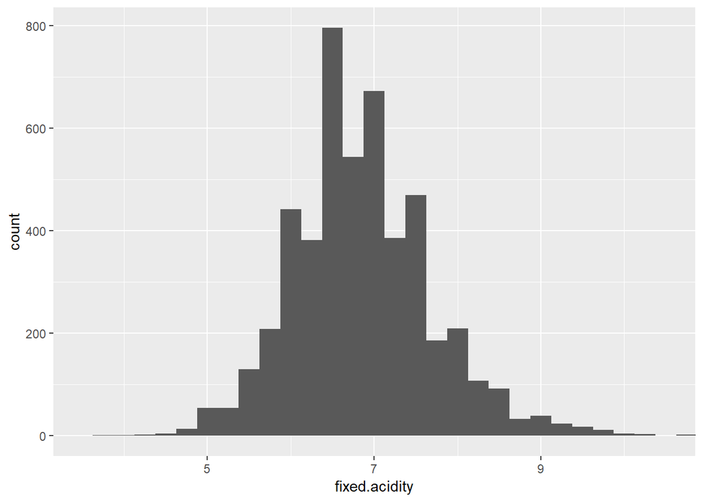

These histograms shows the distribution of tartaric acid in grams acid per liter of wine.

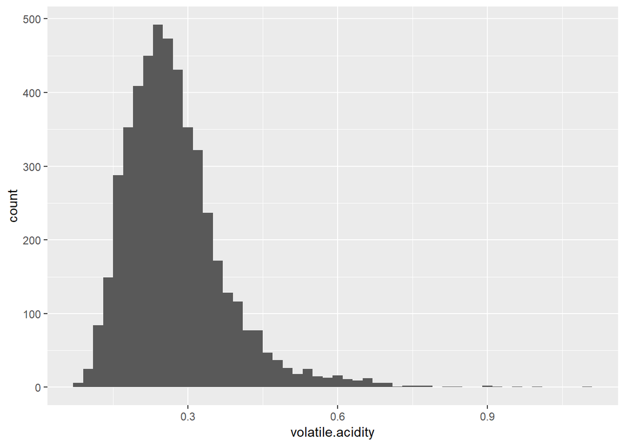

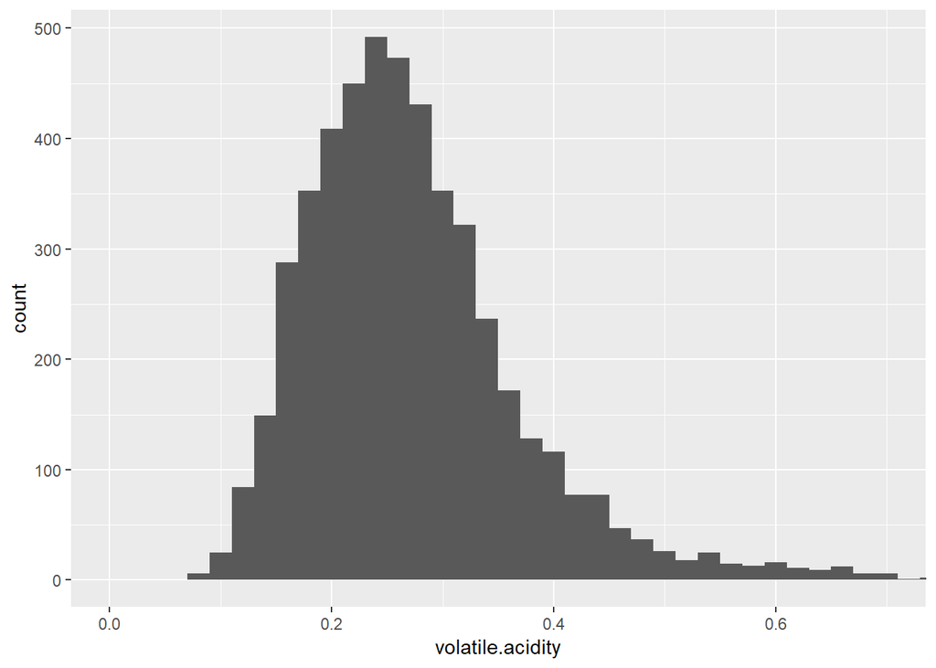

These histograms show the distribution of acetic acid in the wines. The data is slightly skewed-right, but not enough to warrant a log transformation. Wines with high levels of volatile acidity may be good for cooking, since they often have a vinegar-like taste.

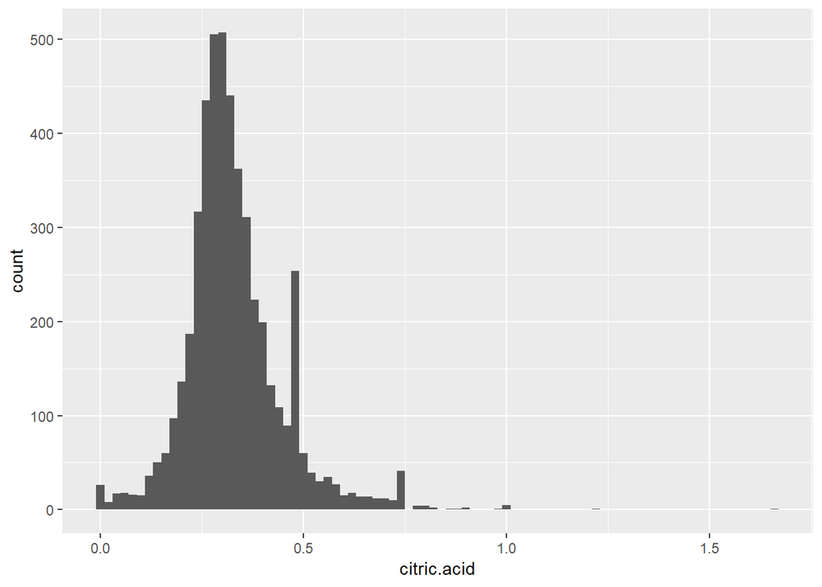

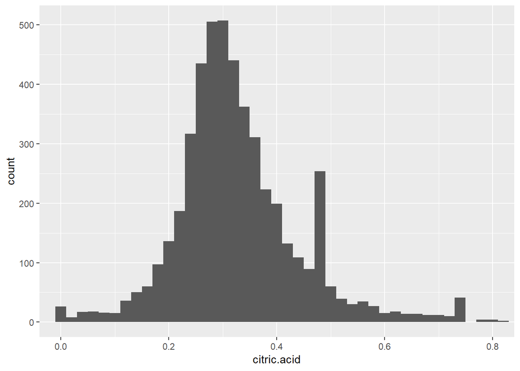

These histograms show the distribution of citric acid in the wines. I wonder how this affects the quality rating of the wines, if mediocre levels have higher quality ratings or not.

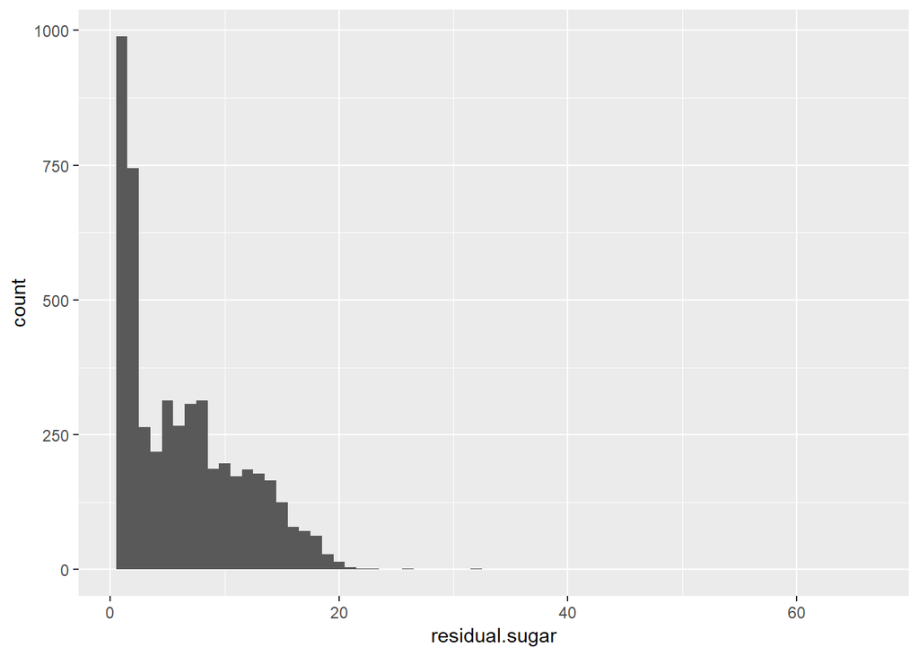

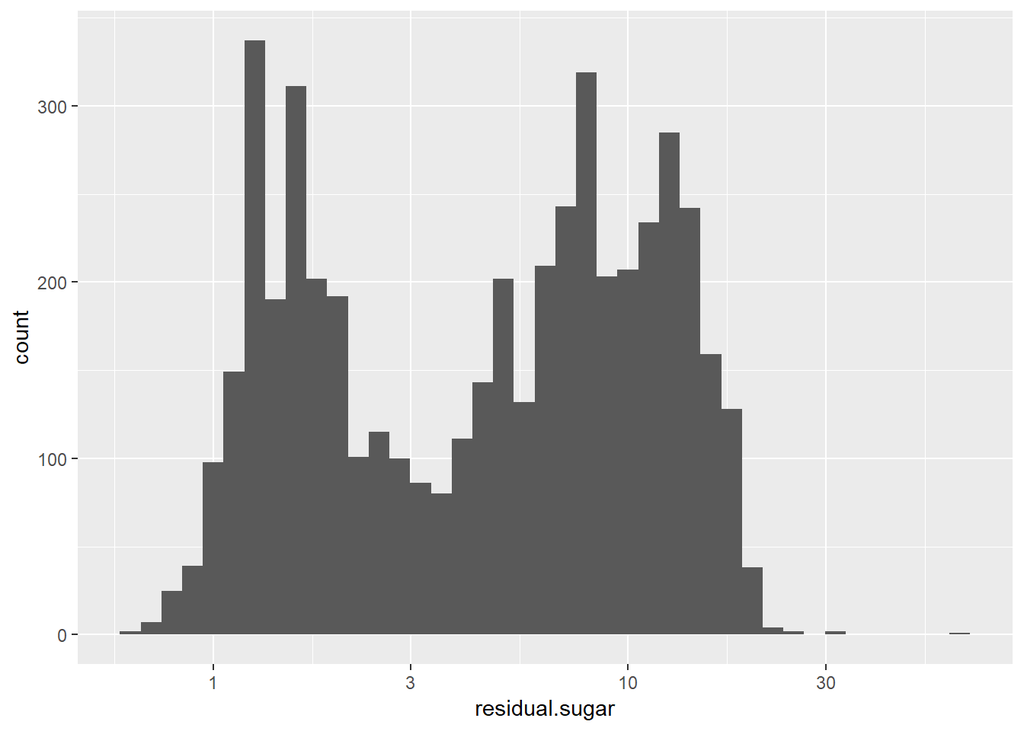

These histograms show the distribution of residual sugars found in the wines. I felt like the data was sufficiently skewed-right to try a log transformation on the data. We can see interesting bimodal behavior here. I would think that higher residual sugars would lead to a better tasting and thus better quality wine.

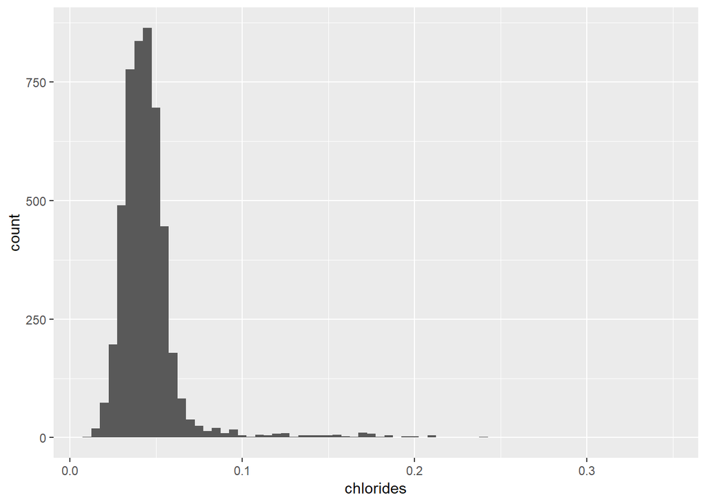

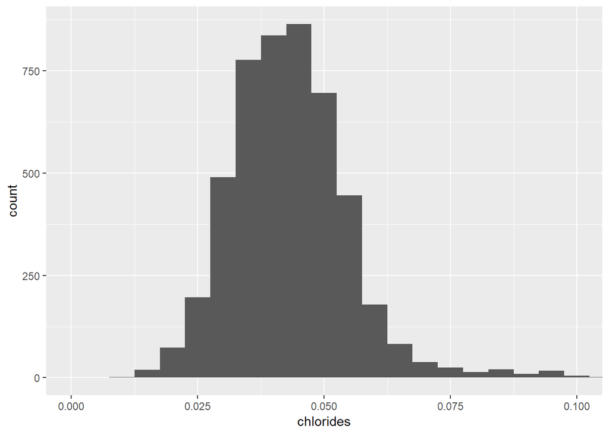

These histograms show the distribution of the chlorides or salt in the wines.

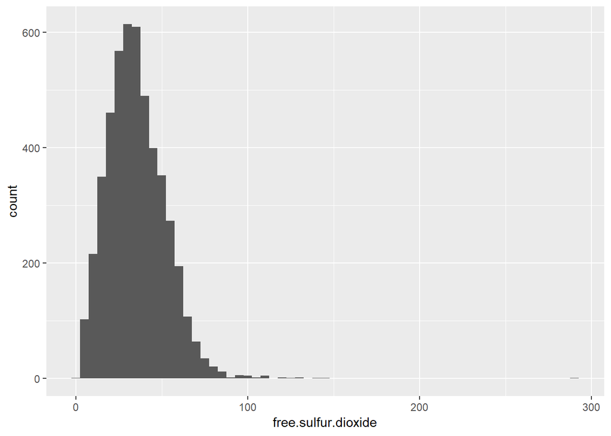

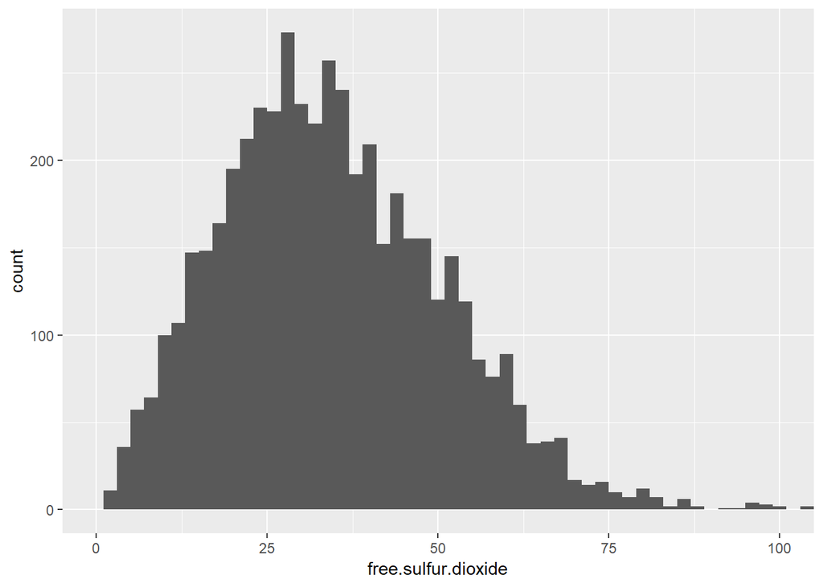

These plots show the distribution of free sulfur dioxide (this prevents microbial growth and oxidation of wines).

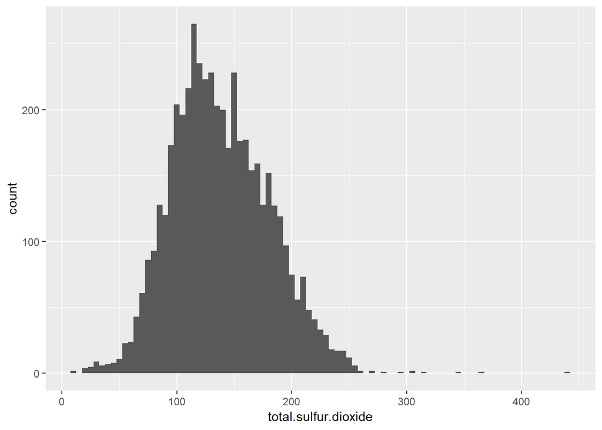

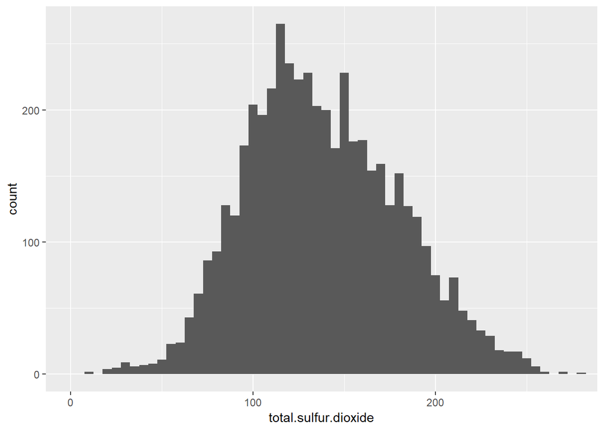

These histograms show us the distibution of total sulfur dioxide. High levels of sulfur dioxide can affect the taste of wines.

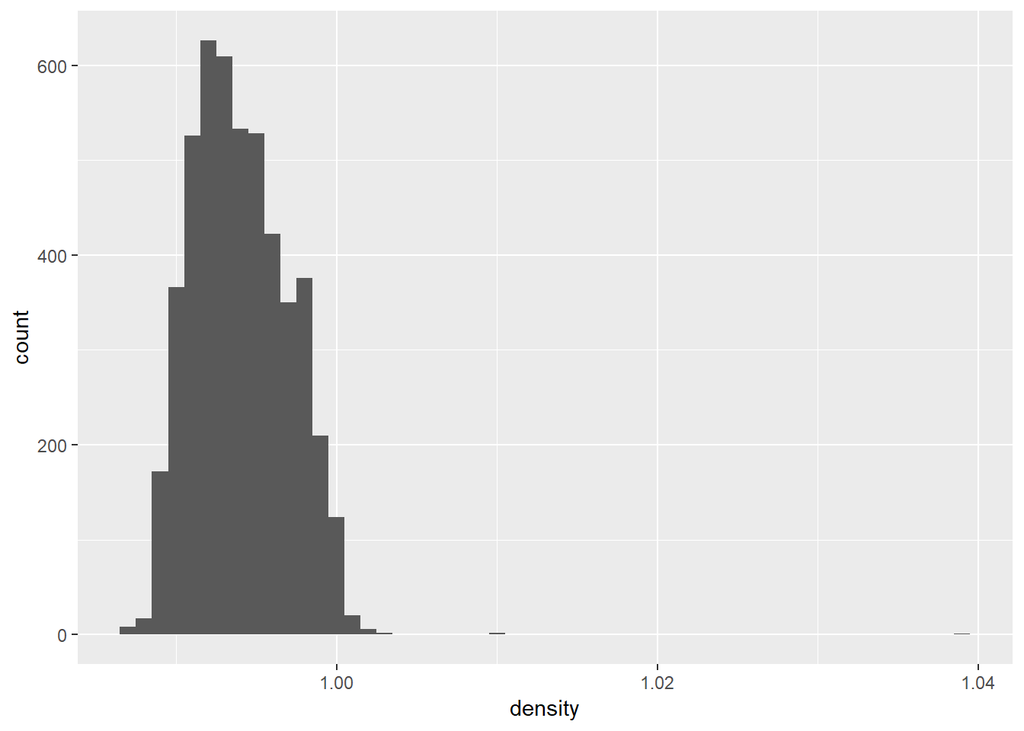

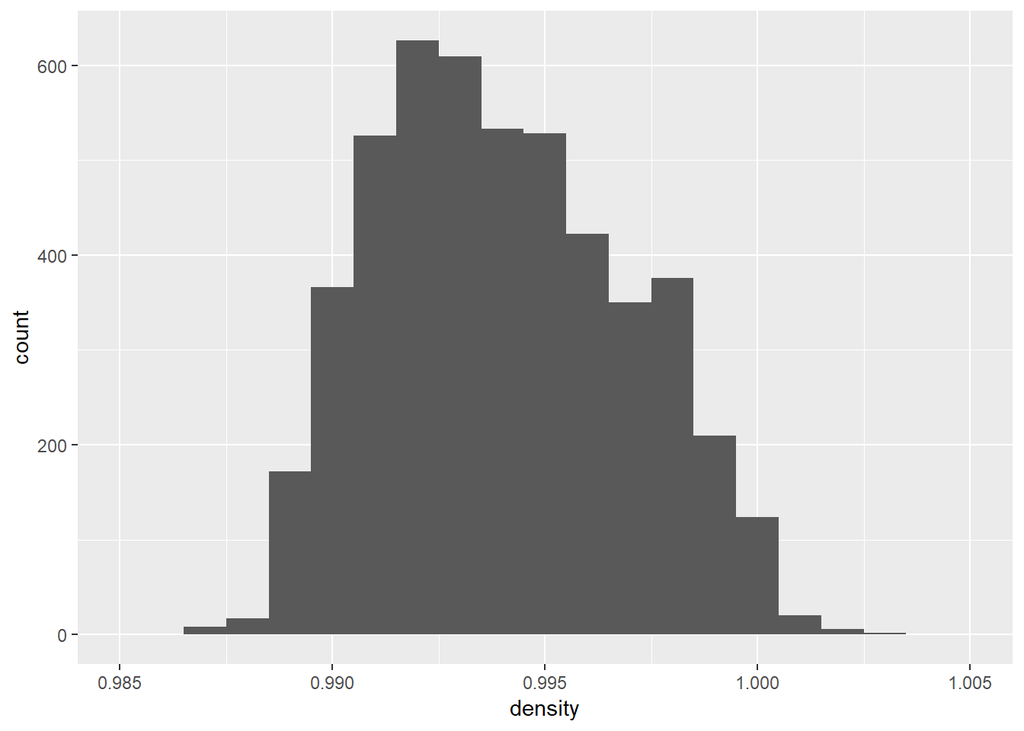

These plots show us the distribution of the density of the wines. Nothing really seems amiss here, the density of alcohol is less than that of water (which has a density of 1).

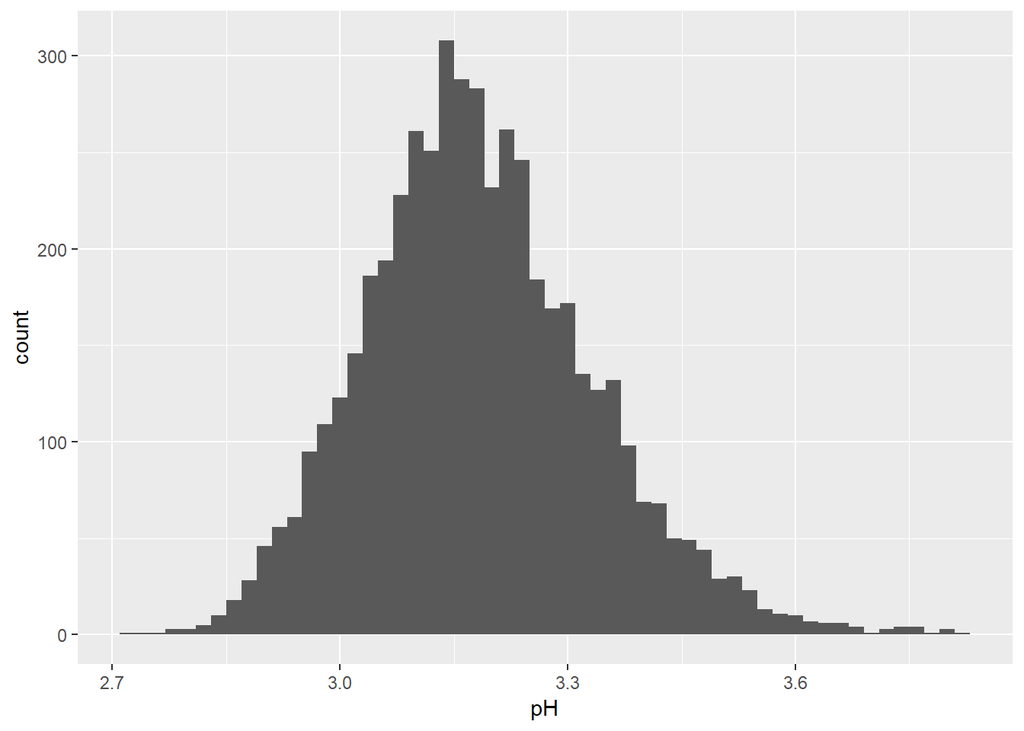

This distribution shows us the distribution of the pH levels of the wines. I would assume these correlate with the acidity values.

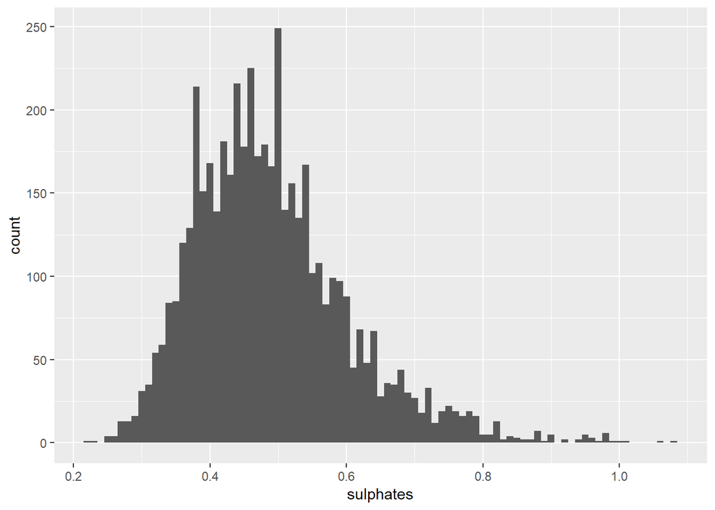

This histogram shows us the distribution of the sulphates in the wines. It is slightly skewed-right, but not very much.

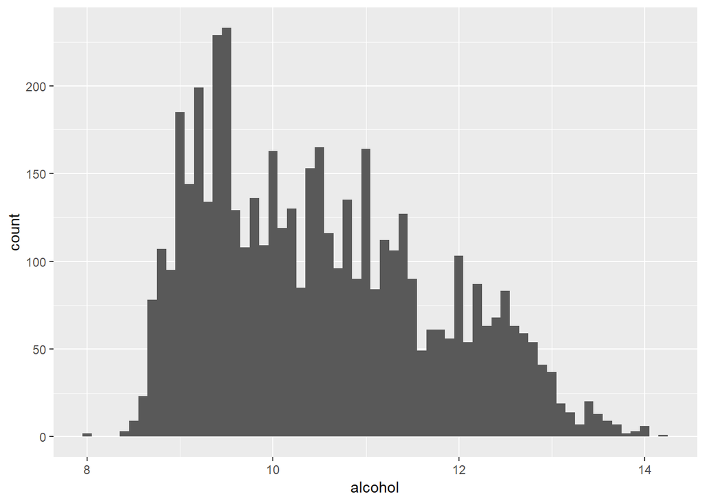

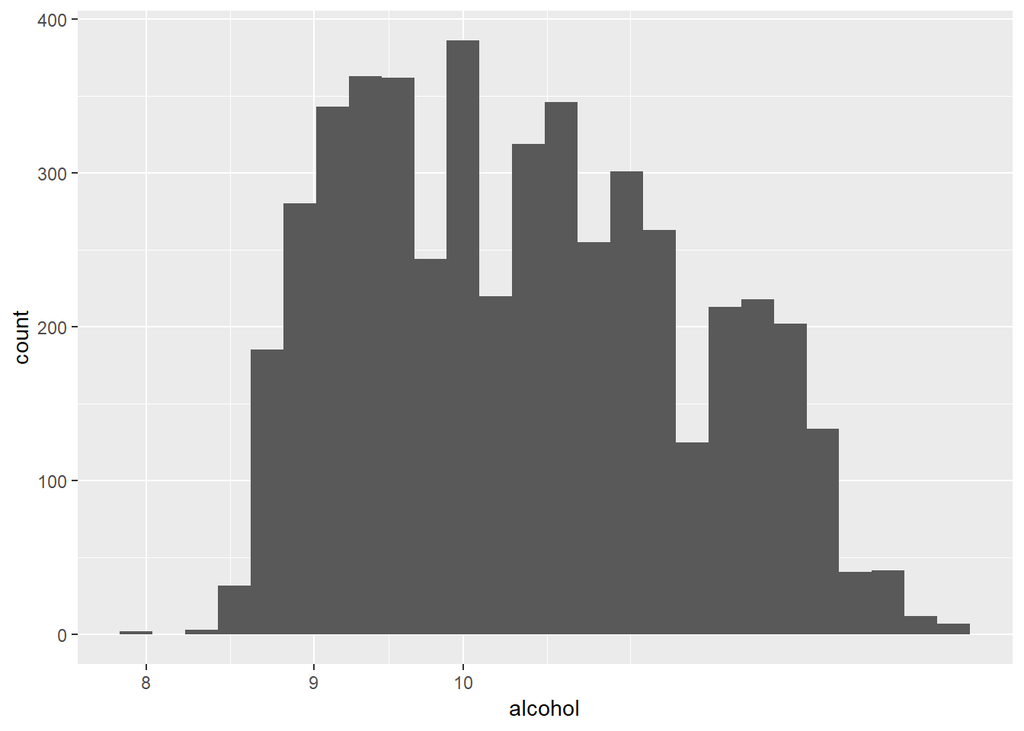

These plots show the distribution of the % alcohol of the wines. The data is slightly skewed-right, so I also plotted it with a log transformation. I don’t know that the log transform really does anything to help us understand the data. It would be interesting to see how the % alcohol correlates with the quality score.

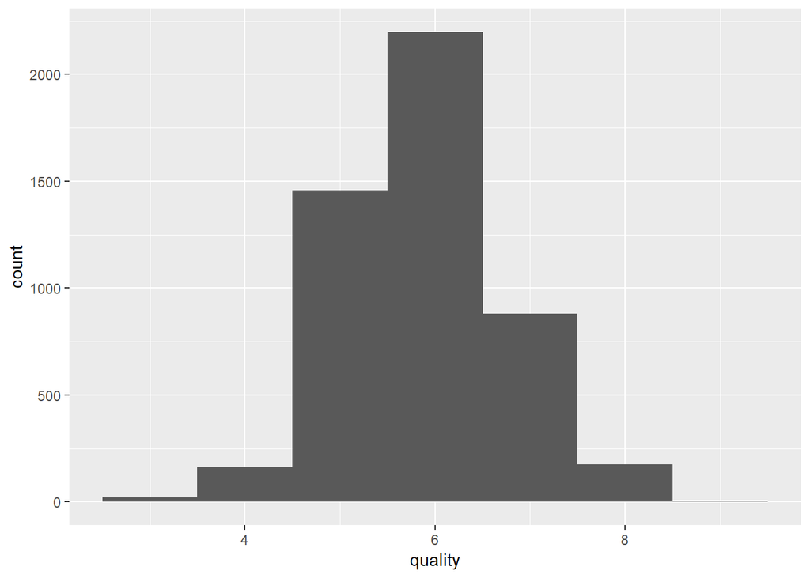

This histogram shows the distribution of the quality scores of the wine. They were give on a scale from 0 to 10. The scores only fall between three and nine. Quality for wine is an interesting metric because it gives an objective value to something that is actually inherently subjective (see https://www.dummies.com/food-drink/drinks/wine/rating-wine-quality/ ).

```
## # A tibble: 7 x 2
##   quality no_rows
##     <int>   <int>
## 1       3      20
## 2       4     163
## 3       5    1457
## 4       6    2198
## 5       7     880
## 6       8     175
## 7       9       5
```

I’ve heard people talk about a wine being dry. After doing some research, there are many levels of dryness, so I decided to create a factor to see how many types of wines were in the data set (the factors were based off of the infographic on this website https://winefolly.com/review/what-is-residual-sugar-in-wine/ ). Most of the wines that we have data for are dry. Since the distribution isn’t even, I don’t know how useful this factor will be.

```
## # A tibble: 4 x 2
##   dryness      no_rows
##   <fct>          <int>
## 1 bone_dry          77
## 2 dry             4660
## 3 off_dry          160
## 4 medium_sweet       1
```

# Univariate Analysis

### What is the structure of your dataset?

There are 4,898 wines in the dataset with 12 attributes (fixed acidity, volatile acidity, citric acid, residual sugar, chlorides, free sulfur dioxide, total sulfur dioxide, density, pH, sulphates, alcohol, and quality).

I had a few other observations:

- 95.1% of the wines can be classified as dry.
- The median amount of residual sugar is 5.2 g/L and the max is 65.8 g/L.
- 92.6% of the wines have a quality rating of 5, 6, or 7 with the most of these having a quality score of 6.

### What is/are the main feature(s) of interest in your dataset?

I would say that the man features of interest for me are citric acid, residual sugar, alcohol and quality. I don’t think I’ll be able to determine which wines are best for cooking from this dataset, but I think the right combination of these attributes would make for the highest quality wine.

I think that the volatile and fixed acidity may help support my investigation. The chlorides may also help.

### Did you create any new variables from existing variables in the dataset?

I have often heard people talk about a wine being ‘dry.’ The dryness of a wine can be determined by how much residual sugar there is in the wine. I created a factor based on some information I found. A wine with less than 1 g/L of residual sugar would be considered ‘bone dry.’ ‘Dry’ wines have between 1 g/L and 17 g/L residual sugar. ‘Off dry’ wines have up to 35 g/L residual sugar. ‘Medium sweet’ wines will have between 35 g/L residual sugar and 120 g/L residual sugar. Any wine with over 120 g/L residual sugar would be considered sweet. Most wines in this dataset would fall in the ‘dry’ category.

### Of the features you investigated, were there any unusual distributions?

I was lucky and my dataset was already tidy and wasn’t missing any data. I did perform a log transformation on the residual sugar and alcohol columns. The alcohol column wasn’t very skewed-right and I didn’t feel that the log transformation really helped me understand the data better. However, the transform of residual sugar was very interesting. The distribution appears to be bimodal with peaks at approximately 1.5 g/L and 10 g/L.

# Bivariate Plots Section

```
##                      fixed.acidity volatile.acidity citric.acid
## fixed.acidity                 1.00            -0.02        0.29
## volatile.acidity             -0.02             1.00       -0.15
## citric.acid                   0.29            -0.15        1.00
## residual.sugar                0.09             0.06        0.09
## chlorides                     0.02             0.07        0.11
## free.sulfur.dioxide          -0.05            -0.10        0.09
## total.sulfur.dioxide          0.09             0.09        0.12
## density                       0.27             0.03        0.15
## pH                           -0.43            -0.03       -0.16
## sulphates                    -0.02            -0.04        0.06
## alcohol                      -0.12             0.07       -0.08
## quality                      -0.11            -0.19       -0.01
##                      residual.sugar chlorides free.sulfur.dioxide
## fixed.acidity                  0.09      0.02               -0.05
## volatile.acidity               0.06      0.07               -0.10
## citric.acid                    0.09      0.11                0.09
## residual.sugar                 1.00      0.09                0.30
## chlorides                      0.09      1.00                0.10
## free.sulfur.dioxide            0.30      0.10                1.00
## total.sulfur.dioxide           0.40      0.20                0.62
## density                        0.84      0.26                0.29
## pH                            -0.19     -0.09                0.00
## sulphates                     -0.03      0.02                0.06
## alcohol                       -0.45     -0.36               -0.25
## quality                       -0.10     -0.21                0.01
##                      total.sulfur.dioxide density    pH sulphates alcohol
## fixed.acidity                        0.09    0.27 -0.43     -0.02   -0.12
## volatile.acidity                     0.09    0.03 -0.03     -0.04    0.07
## citric.acid                          0.12    0.15 -0.16      0.06   -0.08
## residual.sugar                       0.40    0.84 -0.19     -0.03   -0.45
## chlorides                            0.20    0.26 -0.09      0.02   -0.36
## free.sulfur.dioxide                  0.62    0.29  0.00      0.06   -0.25
## total.sulfur.dioxide                 1.00    0.53  0.00      0.13   -0.45
## density                              0.53    1.00 -0.09      0.07   -0.78
## pH                                   0.00   -0.09  1.00      0.16    0.12
## sulphates                            0.13    0.07  0.16      1.00   -0.02
## alcohol                             -0.45   -0.78  0.12     -0.02    1.00
## quality                             -0.17   -0.31  0.10      0.05    0.44
##                      quality
## fixed.acidity          -0.11
## volatile.acidity       -0.19
## citric.acid            -0.01
## residual.sugar         -0.10
## chlorides              -0.21
## free.sulfur.dioxide     0.01
## total.sulfur.dioxide   -0.17
## density                -0.31
## pH                      0.10
## sulphates               0.05
## alcohol                 0.44
## quality                 1.00
```

The residual sugar value has a strong correlation with density. The free sulfur dioxide and total sulfur dioxide also correlate, which makes sense since free sulfur dioxide is a subset of total sulfur dioxide. The strongest correlation with quality is the measure of alcohol in the wine which is also interesting.

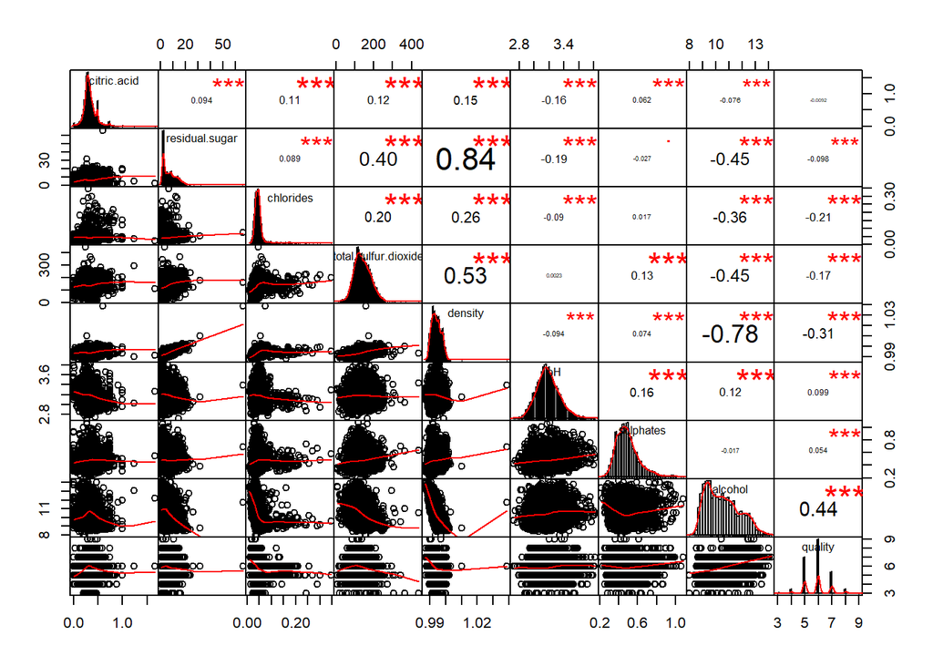

I want to examine a little about the relationship between the acids listed in the dataset. It appears that volatile acidity and fixed acidity don’t really correlate with each other.

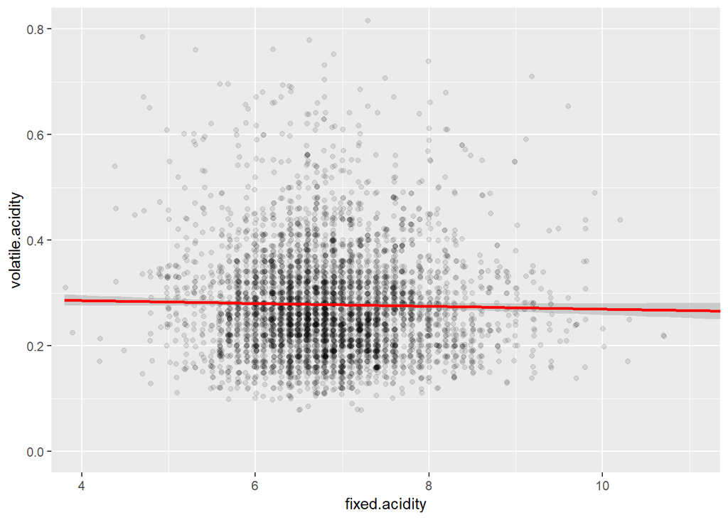

Citric acid and volatile acidity have a slight negative correlation.

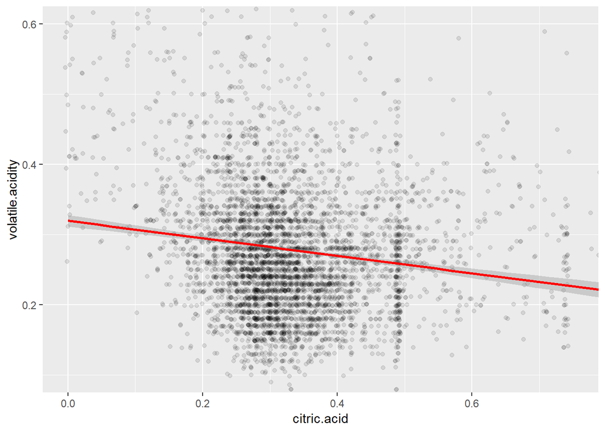

Citric acid and fixed acidity have a slight positive correlation. I would guess that citric acid is probably a subset of fixed acidity.

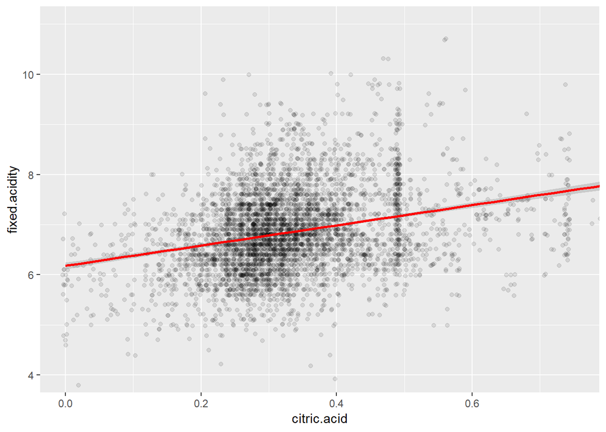

There is an interesting grouping of wines with a citric acid level of approximately 0.5 g/L. I wonder if all these wines are fermented in the same way or made by the same manufacturer. There could be some other scientific explanation as well.

We can also see the negative relationship between acidity and pH beow. As the fixed acidity increases pH decreases.

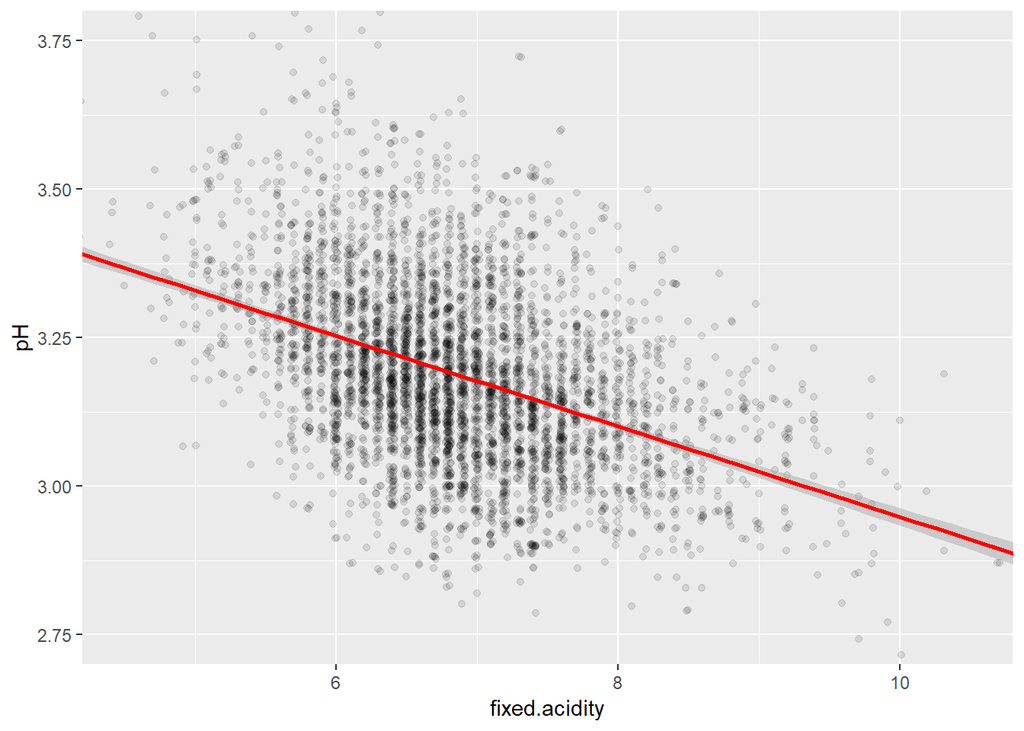

We can also see the relationship between the free sulfur dioxide and the total sulfur dioxide. As stated above, this makes sense because free sulfur dioxide would be a subset of the total sulfur dioxide.

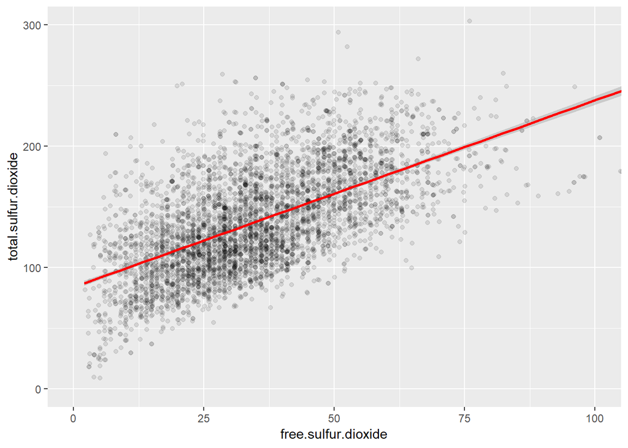

The relationship between residual sugar and density was one that I didn’t really think about beforehand, but it does make sense. The more sugar is left in the wine at the end of its fermentation process, the more weighty it will be and will thus have a greater density.

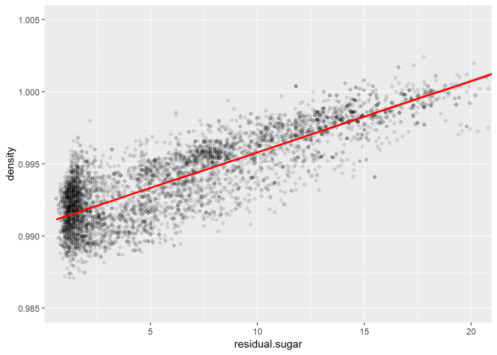

The correlation between residual sugar and alcohol is also interesting. I’m not sure why they would be negatively correlated.

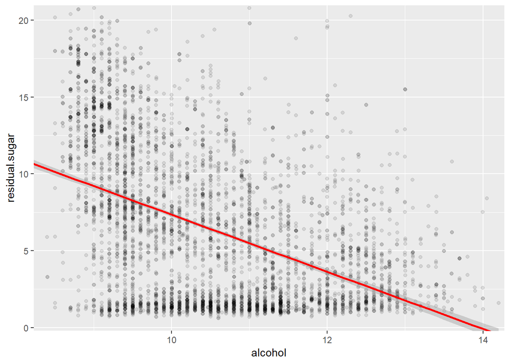

After I did a little research, the correlation between density and alcohol also makes sense. Alcohol is less dense than water (which has a density of 1), so the more alcohol is in the wine, the less dense it will be.